# CSCN8000 – Artificial Intelligence Algorithms and Mathematics – Winter 2024 _ Lab 3

## 9000400

## Introduction:

In this notebook, we delve into the challenge of detecting fraudulent credit card transactions, leveraging a dataset that encapsulates transactions made by European cardholders in September 2013. This dataset, notable for its real-world applicability and the critical issue of fraud detection it addresses, comprises 284,807 transactions, of which 492 are frauds.  
So lets descover the data:

```python
import pandas as pd

creditcard_df = pd.read_csv('creditcard.csv')

creditcard_df
```

|  | Time | V1 | V2 | V3 | V4 | V5 | V6 | V7 | V8 | V9 | ... | V21 | V22 | V23 | V24 | V25 | V26 | V27 | V28 | Amount | Class |
| --- | --- | --- | --- | --- | --- | --- | --- | --- | --- | --- | --- | --- | --- | --- | --- | --- | --- | --- | --- | --- | --- |
| 0 | 0.0 | -1.359807 | -0.072781 | 2.536347 | 1.378155 | -0.338321 | 0.462388 | 0.239599 | 0.098698 | 0.363787 | ... | -0.018307 | 0.277838 | -0.110474 | 0.066928 | 0.128539 | -0.189115 | 0.133558 | -0.021053 | 149.62 | 0 |
| 1 | 0.0 | 1.191857 | 0.266151 | 0.166480 | 0.448154 | 0.060018 | -0.082361 | -0.078803 | 0.085102 | -0.255425 | ... | -0.225775 | -0.638672 | 0.101288 | -0.339846 | 0.167170 | 0.125895 | -0.008983 | 0.014724 | 2.69 | 0 |
| 2 | 1.0 | -1.358354 | -1.340163 | 1.773209 | 0.379780 | -0.503198 | 1.800499 | 0.791461 | 0.247676 | -1.514654 | ... | 0.247998 | 0.771679 | 0.909412 | -0.689281 | -0.327642 | -0.139097 | -0.055353 | -0.059752 | 378.66 | 0 |
| 3 | 1.0 | -0.966272 | -0.185226 | 1.792993 | -0.863291 | -0.010309 | 1.247203 | 0.237609 | 0.377436 | -1.387024 | ... | -0.108300 | 0.005274 | -0.190321 | -1.175575 | 0.647376 | -0.221929 | 0.062723 | 0.061458 | 123.50 | 0 |
| 4 | 2.0 | -1.158233 | 0.877737 | 1.548718 | 0.403034 | -0.407193 | 0.095921 | 0.592941 | -0.270533 | 0.817739 | ... | -0.009431 | 0.798278 | -0.137458 | 0.141267 | -0.206010 | 0.502292 | 0.219422 | 0.215153 | 69.99 | 0 |
| ... | ... | ... | ... | ... | ... | ... | ... | ... | ... | ... | ... | ... | ... | ... | ... | ... | ... | ... | ... | ... | ... |
| 284802 | 172786.0 | -11.881118 | 10.071785 | -9.834783 | -2.066656 | -5.364473 | -2.606837 | -4.918215 | 7.305334 | 1.914428 | ... | 0.213454 | 0.111864 | 1.014480 | -0.509348 | 1.436807 | 0.250034 | 0.943651 | 0.823731 | 0.77 | 0 |
| 284803 | 172787.0 | -0.732789 | -0.055080 | 2.035030 | -0.738589 | 0.868229 | 1.058415 | 0.024330 | 0.294869 | 0.584800 | ... | 0.214205 | 0.924384 | 0.012463 | -1.016226 | -0.606624 | -0.395255 | 0.068472 | -0.053527 | 24.79 | 0 |
| 284804 | 172788.0 | 1.919565 | -0.301254 | -3.249640 | -0.557828 | 2.630515 | 3.031260 | -0.296827 | 0.708417 | 0.432454 | ... | 0.232045 | 0.578229 | -0.037501 | 0.640134 | 0.265745 | -0.087371 | 0.004455 | -0.026561 | 67.88 | 0 |
| 284805 | 172788.0 | -0.240440 | 0.530483 | 0.702510 | 0.689799 | -0.377961 | 0.623708 | -0.686180 | 0.679145 | 0.392087 | ... | 0.265245 | 0.800049 | -0.163298 | 0.123205 | -0.569159 | 0.546668 | 0.108821 | 0.104533 | 10.00 | 0 |
| 284806 | 172792.0 | -0.533413 | -0.189733 | 0.703337 | -0.506271 | -0.012546 | -0.649617 | 1.577006 | -0.414650 | 0.486180 | ... | 0.261057 | 0.643078 | 0.376777 | 0.008797 | -0.473649 | -0.818267 | -0.002415 | 0.013649 | 217.00 | 0 |

284807 rows × 31 columns

As we can see here we have 31 featers:  
These features primarily transformed via PCA to ensure confidentiality.  
Features V1, V2, … V28 are the principal components obtained with PCA, the only features which have not been transformed with PCA are 'Time' and 'Amount'. Feature 'Time' contains the seconds elapsed between each transaction and the first transaction in the dataset. The feature 'Amount' is the transaction Amount. Feature 'Class' is the response variable and it takes value 1 in case of fraud and 0 otherwise. The data is highly unbalanced, with fraudulent transactions making up only 0.172% of the total, underscoring the rarity and difficulty of detecting such activities.

Source:https://www.kaggle.com/datasets/mlg-ulb/creditcardfraud/data

## Data Preprocessing

1. Detect and handle outlier

Visualizing Outliers with Boxplots  
Visualizing give us a clear picture of outliers.I will use Boxplots for that.Boxplots are excellent for spotting outliers across multiple features at once. Since the dataset likely contains a large number of features (V1 to V28, Amount, and possibly Time), creating a boxplot for each can quickly give you an idea of where outliers might be.

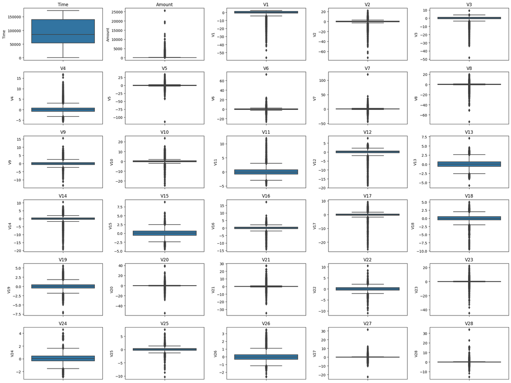

```python
import matplotlib.pyplot as plt
import seaborn as sns

# Selecting numerical features for visualization
# Assuming 'Time' and 'Amount' are the only non-PCA features that are numerical
features = ['Time', 'Amount'] + ['V' + str(i) for i in range(1, 29)]

# Plotting boxplots for each feature
plt.figure(figsize=(20, 15))
for i, feature in enumerate(features):
    plt.subplot(6, 5, i + 1)  # Adjust the grid size according to the number of features
    sns.boxplot(y=creditcard_df[feature])
    plt.title(feature)
    plt.tight_layout()

plt.show()
```

as we can see in the plot, the features V1 to V28,contain many outliers. After visualizing and confirming the presence of outliers in your dataset, the next step is to detect and handle these outliers systematically

```python
# Calculating IQR for each feature
Q1 = creditcard_df.quantile(0.25)
Q3 = creditcard_df.quantile(0.75)
IQR = Q3 - Q1

# Identifying outliers
is_outlier_iqr = ((creditcard_df < (Q1 - 2.5 * IQR)) | (creditcard_df > (Q3 + 1.5 * IQR)))
outliers_iqr = is_outlier_iqr.any(axis=1)
num_outliers_iqr = outliers_iqr.sum()

print(f"Number of outliers detected by the IQR method: {num_outliers_iqr}")
```

```
Number of outliers detected by the IQR method: 116208
```

```python
from scipy import stats
import numpy as np

# Calculating Z-scores for each feature
z = np.abs(stats.zscore(creditcard_df, nan_policy='omit'))
threshold = 4
is_outlier_z = (z > threshold)
outliers_z = is_outlier_z.any(axis=1)
num_outliers_z = outliers_z.sum()

print(f"Number of outliers detected by the Z-score method: {num_outliers_z}")
```

```
Number of outliers detected by the Z-score method: 14560
```

The IQR method detected a higher number of outliers compared to the Z-score method. This difference suggests that the IQR method is more sensitive to unusual data points in this dataset, likely because it relies on quartile measures that can pick up outliers in data that doesn't follow a normal (Gaussian) distribution or is skewed. On the other hand, the Z-score method, which calculates how far a point is from the mean in terms of standard deviations, found fewer outliers. This indicates it's less sensitive to deviations, assuming the data has a normal distribution. In simpler terms, the IQR method is better at spotting outliers in more varied data, while the Z-score method focuses on extreme cases in data that's expected to be normally distributed.  
so i will make a new dataframe wtih cleaned data based on the IQR:

```python
# I want to keep a copy of the original DataFrame for comparison
original_df_copy = creditcard_df.copy()
# Creating a new DataFrame without the outliers
cleaned_df_iqr = creditcard_df[~outliers_iqr]
cleaned_df_iqr.head()
```

|  | Time | V1 | V2 | V3 | V4 | V5 | V6 | V7 | V8 | V9 | ... | V21 | V22 | V23 | V24 | V25 | V26 | V27 | V28 | Amount | Class |
| --- | --- | --- | --- | --- | --- | --- | --- | --- | --- | --- | --- | --- | --- | --- | --- | --- | --- | --- | --- | --- | --- |
| 0 | 0.0 | -1.359807 | -0.072781 | 2.536347 | 1.378155 | -0.338321 | 0.462388 | 0.239599 | 0.098698 | 0.363787 | ... | -0.018307 | 0.277838 | -0.110474 | 0.066928 | 0.128539 | -0.189115 | 0.133558 | -0.021053 | 149.62 | 0 |
| 1 | 0.0 | 1.191857 | 0.266151 | 0.166480 | 0.448154 | 0.060018 | -0.082361 | -0.078803 | 0.085102 | -0.255425 | ... | -0.225775 | -0.638672 | 0.101288 | -0.339846 | 0.167170 | 0.125895 | -0.008983 | 0.014724 | 2.69 | 0 |
| 3 | 1.0 | -0.966272 | -0.185226 | 1.792993 | -0.863291 | -0.010309 | 1.247203 | 0.237609 | 0.377436 | -1.387024 | ... | -0.108300 | 0.005274 | -0.190321 | -1.175575 | 0.647376 | -0.221929 | 0.062723 | 0.061458 | 123.50 | 0 |
| 4 | 2.0 | -1.158233 | 0.877737 | 1.548718 | 0.403034 | -0.407193 | 0.095921 | 0.592941 | -0.270533 | 0.817739 | ... | -0.009431 | 0.798278 | -0.137458 | 0.141267 | -0.206010 | 0.502292 | 0.219422 | 0.215153 | 69.99 | 0 |
| 5 | 2.0 | -0.425966 | 0.960523 | 1.141109 | -0.168252 | 0.420987 | -0.029728 | 0.476201 | 0.260314 | -0.568671 | ... | -0.208254 | -0.559825 | -0.026398 | -0.371427 | -0.232794 | 0.105915 | 0.253844 | 0.081080 | 3.67 | 0 |

5 rows × 31 columns

### 2.Normalization:

as i noticed all the values for the features V1 to V28, looks like all in same range, I think the reson is becouse they are result of PCA transformation. however the feature "Amount" and "time",looks like have a deffrent range of valuse (not between 0-1).below I wil try to normalize them using Standardization (Z-score normalization)

```python
from sklearn.preprocessing import StandardScaler

# Creating a copy of the dataset to keep the original data unchanged
scaled_df = creditcard_df.copy()

# Initializing the StandardScaler
scaler = StandardScaler()

# Standardizing "Time" and "Amount"
scaled_df[['Time', 'Amount']] = scaler.fit_transform(scaled_df[['Time', 'Amount']])

# Now, 'scaled_df' has the 'Time' and 'Amount' features standardized.
scaled_df.head()
```

|  | Time | V1 | V2 | V3 | V4 | V5 | V6 | V7 | V8 | V9 | ... | V21 | V22 | V23 | V24 | V25 | V26 | V27 | V28 | Amount | Class |
| --- | --- | --- | --- | --- | --- | --- | --- | --- | --- | --- | --- | --- | --- | --- | --- | --- | --- | --- | --- | --- | --- |
| 0 | -1.996583 | -1.359807 | -0.072781 | 2.536347 | 1.378155 | -0.338321 | 0.462388 | 0.239599 | 0.098698 | 0.363787 | ... | -0.018307 | 0.277838 | -0.110474 | 0.066928 | 0.128539 | -0.189115 | 0.133558 | -0.021053 | 0.244964 | 0 |
| 1 | -1.996583 | 1.191857 | 0.266151 | 0.166480 | 0.448154 | 0.060018 | -0.082361 | -0.078803 | 0.085102 | -0.255425 | ... | -0.225775 | -0.638672 | 0.101288 | -0.339846 | 0.167170 | 0.125895 | -0.008983 | 0.014724 | -0.342475 | 0 |
| 2 | -1.996562 | -1.358354 | -1.340163 | 1.773209 | 0.379780 | -0.503198 | 1.800499 | 0.791461 | 0.247676 | -1.514654 | ... | 0.247998 | 0.771679 | 0.909412 | -0.689281 | -0.327642 | -0.139097 | -0.055353 | -0.059752 | 1.160686 | 0 |
| 3 | -1.996562 | -0.966272 | -0.185226 | 1.792993 | -0.863291 | -0.010309 | 1.247203 | 0.237609 | 0.377436 | -1.387024 | ... | -0.108300 | 0.005274 | -0.190321 | -1.175575 | 0.647376 | -0.221929 | 0.062723 | 0.061458 | 0.140534 | 0 |
| 4 | -1.996541 | -1.158233 | 0.877737 | 1.548718 | 0.403034 | -0.407193 | 0.095921 | 0.592941 | -0.270533 | 0.817739 | ... | -0.009431 | 0.798278 | -0.137458 | 0.141267 | -0.206010 | 0.502292 | 0.219422 | 0.215153 | -0.073403 | 0 |

5 rows × 31 columns

## Descriptive Analytics Tasks

**Analyze the distribution of fraud vs non-fraud transactions** for Analyzing the distribution of the data ,i will calculate the Variance and the Standard Deviation:

```python
# Calculating the variance of the 'Class' variable
class_variance = creditcard_df['Class'].var()
print(f"Variance of the Class variable: {class_variance}")

# Calculating the standard deviation of the 'Class' variable
class_std_dev = creditcard_df['Class'].std()
print(f"Standard Deviation of the Class variable: {class_std_dev}")
```

```
Variance of the Class variable: 0.001724507479019877
Standard Deviation of the Class variable: 0.04152718963546506
```

```python
# Calculating the variance of the 'Class' variable
class_variance = scaled_df['Class'].var()
print(f"Variance of the Class variable: {class_variance}")

# Calculating the standard deviation of the 'Class' variable
class_std_dev = scaled_df['Class'].std()
print(f"Standard Deviation of the Class variable: {class_std_dev}")
```

```
Variance of the Class variable: 0.001724507479019877
Standard Deviation of the Class variable: 0.04152718963546506
```

Variance: 0.001724507479019877 What It Means: The variance tells us how much the fraud and non-fraud labels vary from the average. A low variance here means that most transactions are very similar in terms of being fraud or not. Since we know fraud cases are rare, this low number mainly tells us that the vast majority of transactions are not fraud.  
The standard deviation also looks at how spread out the fraud and non-fraud transactions are, but in a way that's easier to understand because it's in the same "units" as our data. A low standard deviation confirms that our transactions don't vary much from the average, meaning again that we have a lot of non-fraud transactions and very few fraud ones.

**correlation** Analyze the correlation between fraud/non-fraud transactions and all the other numerical features.

```
Correlation of 'Class' with other features:
Class     1.000000
V11       0.154876
V4        0.133447
V2        0.091289
V21       0.040413
V19       0.034783
V20       0.020090
V8        0.019875
V27       0.017580
V28       0.009536
Amount    0.005632
V26       0.004455
V25       0.003308
V22       0.000805
V23      -0.002685
V15      -0.004223
V13      -0.004570
V24      -0.007221
Time     -0.012323
V6       -0.043643
V5       -0.094974
V9       -0.097733
V1       -0.101347
V18      -0.111485
V7       -0.187257
V3       -0.192961
V16      -0.196539
V10      -0.216883
V12      -0.260593
V14      -0.302544
V17      -0.326481
Name: Class, dtype: float64
```

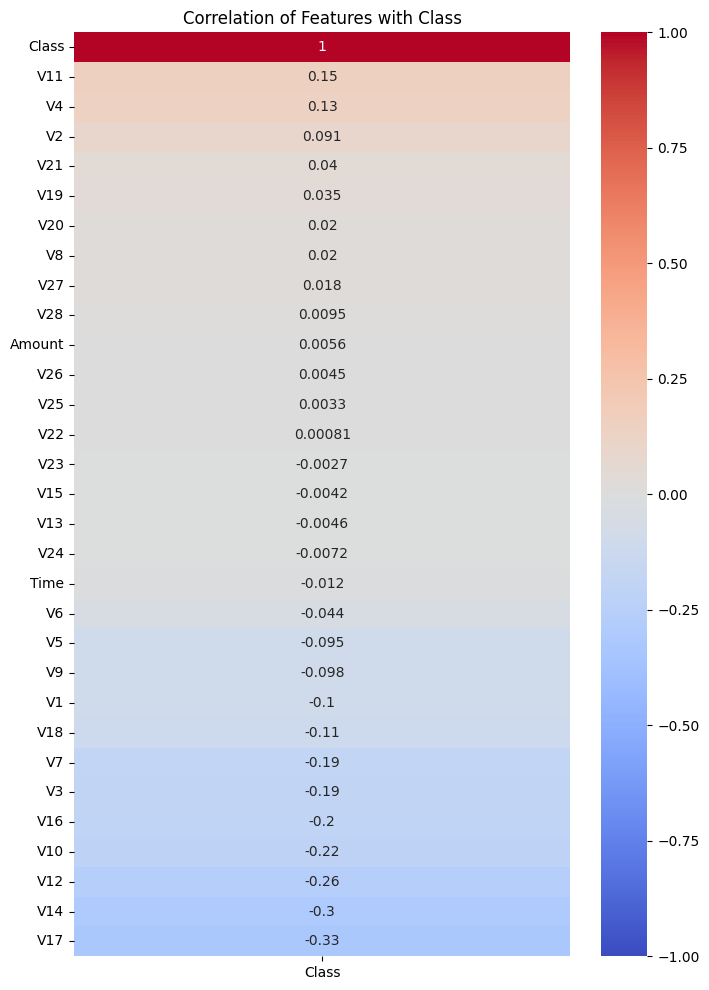

```python
import pandas as pd
import seaborn as sns
import matplotlib.pyplot as plt

# Assuming 'creditcard_df' is your DataFrame

# Calculate the correlation matrix
corr_matrix = creditcard_df.corr()

# Extract the correlations with the 'Class' variable
class_corr = corr_matrix['Class'].sort_values(ascending=False)

# Print the correlation of 'Class' with other features
print("Correlation of 'Class' with other features:")
print(class_corr)

# Visualize the correlation matrix focusing on 'Class'
plt.figure(figsize=(8, 12))
sns.heatmap(corr_matrix[['Class']].sort_values(by='Class', ascending=False), annot=True, cmap='coolwarm', vmin=-1, vmax=1)
plt.title("Correlation of Features with Class")
plt.show()
```

The correlation results show us which details about transactions (like certain patterns or amounts) might tell us if a transaction is likely to be fraud or not. Features like V11, V4, and V2 go up in value in fraud cases, meaning the higher these numbers, the more likely the transaction is fraudulent. On the other hand, features like V17, V14, and V12 go down when a transaction is fraud, so the lower these numbers, the higher the chance of fraud. Some details, like the exact time of the transaction or the amount spent, don't really tell us much about whether it's fraud. This helps us focus on what's important for spotting fraud and can make our fraud detection smarter by paying more attention to these specific details.

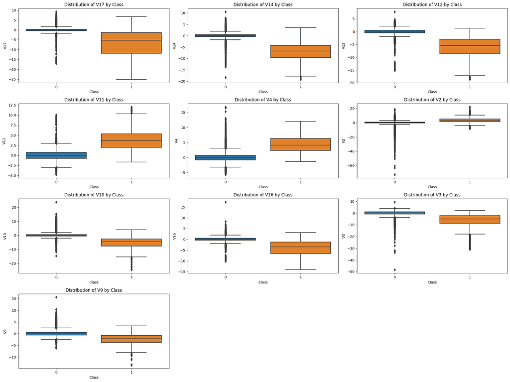

```python
import seaborn as sns
import matplotlib.pyplot as plt

# List of top 10 features based on absolute correlation
top_features = ['V17', 'V14', 'V12', 'V11', 'V4', 'V2', 'V10', 'V16', 'V3', 'V9']

# Set up the matplotlib figure
plt.figure(figsize=(20, 15))

# Plot each of the features
for i, feature in enumerate(top_features, 1):
    plt.subplot(4, 3, i)  # Adjust grid size accordingly
    sns.boxplot(x='Class', y=feature, data=creditcard_df)
    plt.title(f'Distribution of {feature} by Class')

plt.tight_layout()
plt.show()
```

Certain details, such as V17 and V14, really stand out in fraud cases compared to normal ones. For example, when V17's values go down, it's more likely the transaction is fraud. This shows us these details are good clues for spotting fraud.

On the other hand, details like V11 and V4 are higher in fraud transactions. This means when we see higher numbers for these, we should be more suspicious of fraud.

The charts also show a lot of variety in the fraud transactions, meaning not all fraud looks exactly the same. This makes it a bit tricky to catch every fraud but also shows why these details are helpful.

In simple terms, the charts help us see which transaction details are big red flags for fraud. They tell us what to watch out for, making it easier to spot the transactions that aren't right.

## ML Model Training and Testing Tasks

**1.Splitting the data**

```python
from sklearn.model_selection import train_test_split

# Assuming 'cleaned_df' is your cleaned DataFrame and 'Class' is the target variable
X = scaled_df.drop('Class', axis=1)  # Features
y = scaled_df['Class']  # Target variable

# Splitting the dataset into training (80%) and testing (20%) sets
X_train, X_test, y_train, y_test = train_test_split(X, y, test_size=0.2, random_state=42, stratify=y)
X_train.shape, X_test.shape
```

```
((227845, 30), (56962, 30))
```

now lets create a Logistic regression model and use 5-fold cross-validation to evaluate model performance:

```python
from sklearn.linear_model import LogisticRegression
from sklearn.model_selection import cross_val_score

# Initialize the logistic regression model
log_reg = LogisticRegression(max_iter=1000, random_state=42)

# Use 5-fold cross-validation to evaluate model performance
# Note: Adjust 'scoring' as needed (e.g., 'accuracy', 'recall', 'precision', 'f1')
cv_scores = cross_val_score(log_reg, X_train, y_train, cv=5, scoring='accuracy')

print(f"Cross-Validation Accuracy Scores: {cv_scores}")
print(f"Mean CV Accuracy: {cv_scores.mean()}")
```

```
Cross-Validation Accuracy Scores: [0.99912221 0.99914416 0.99923193 0.99929777 0.99920999]
Mean CV Accuracy: 0.9992012113498212
```

**Learned Coefficients (Weights) of the Model**  
After training the logistic regression model, lets fit it to the entire training set to examine the learned coefficients:

```python
# Fit the model to the training data
log_reg.fit(X_train, y_train)

# Print the learned coefficients
print("Learned coefficients (weights):")
print(log_reg.coef_)

# If you have feature names, you can make this more interpretable:
feature_names = X_train.columns
coefficients = log_reg.coef_[0]

for feature, coef in zip(feature_names, coefficients):
    print(f"{feature}: {coef}")
```

```
Learned coefficients (weights):
[[-0.14127332  0.07753562  0.05013765 -0.03244742  0.78153906  0.17212682
  -0.11618982 -0.06458754 -0.15159416 -0.23422602 -0.85531228 -0.08922731
   0.20529397 -0.47424752 -0.56558791 -0.11015769 -0.2984387  -0.08575231
   0.04903757 -0.01563891 -0.49394543  0.3793991   0.60573077 -0.08653664
   0.06525178 -0.1019762   0.05977445 -0.77794385 -0.23467364  0.23882784]]
Time: -0.14127331774816745
V1: 0.07753561605747826
V2: 0.05013764841296887
V3: -0.03244742471194177
V4: 0.7815390575953737
V5: 0.1721268192060338
V6: -0.11618981974176934
V7: -0.06458754304466131
V8: -0.15159415553156666
V9: -0.23422601909232493
V10: -0.8553122798840499
V11: -0.08922731403131973
V12: 0.20529396624086813
V13: -0.474247523158464
V14: -0.5655879117440556
V15: -0.11015769437626267
V16: -0.2984386961567775
V17: -0.08575231234602933
V18: 0.049037568622077775
V19: -0.015638908987986082
V20: -0.49394543473531133
V21: 0.37939910444760444
V22: 0.605730769846772
V23: -0.08653663740418982
V24: 0.06525178130499876
V25: -0.10197620193306485
V26: 0.059774449735537576
V27: -0.7779438471726511
V28: -0.23467364467545077
Amount: 0.23882784192063075
```

Basically, the rule says: the model gave higher weight to the weight vector (feature) that is more effective in the classification. The learned coefficients from the logistic regression model illustrate how each transaction detail (like time, amount, or features labeled V1, V2, etc.) affects the model's fraud detection decisions. Positive numbers indicate an increase in the detail increases the likelihood of fraud, as seen with V4, where higher values strongly suggest fraud. Conversely, negative numbers, such as the significant negative weight for V10, imply that lower values are more indicative of fraud. The magnitude of these numbers, whether positive or negative, signifies the impact level of each detail on the model's ability to predict fraud, guiding it in identifying transactions that should be flagged as suspicious.

**Evaluate the model's performance on the test set**

```python
from sklearn.metrics import accuracy_score, precision_score, recall_score, f1_score

# Assuming log_reg is your trained logistic regression model
# And X_test, y_test are your features and labels for the test set

# Make predictions on the test set
y_pred = log_reg.predict(X_test)

# Calculate metrics
accuracy = accuracy_score(y_test, y_pred)
precision = precision_score(y_test, y_pred)
recall = recall_score(y_test, y_pred)
f1 = f1_score(y_test, y_pred)

print(f"Accuracy: {accuracy}")
print(f"Precision: {precision}")
print(f"Recall: {recall}")
print(f"F1-Score: {f1}")
```

```
Accuracy: 0.9991748885221726
Precision: 0.8311688311688312
Recall: 0.6530612244897959
F1-Score: 0.7314285714285713
```

Accuracy: 0.9991748885221726 (Approximately 99.92%)  
What It Means: The model correctly predicts whether a transaction is fraudulent or not about 99.92% of the time. This high accuracy indicates that the model is very effective overall, especially considering the context of fraud detection where the majority of transactions are legitimate (non-fraudulent).  
Precision: 0.8311688311688312 (Approximately 83.12%)  
What It Means: When the model predicts a transaction is fraudulent, it is correct approximately 83.12% of the time. This is important because it shows that the model has a relatively low rate of false positives (legitimate transactions incorrectly flagged as fraud), which is crucial for minimizing inconvenience to users.  
Recall: 0.6530612244897959 (Approximately 65.31%)  
What It Means: The model correctly identifies approximately 65.31% of all fraudulent transactions. This metric is crucial for fraud detection systems because it measures the model's ability to catch fraud. A higher recall means fewer fraud cases slip through the net, but there's room for improvement here to catch more fraudulent transactions.  
F1-Score: 0.7314285714285713 (Approximately 73.14%)  
What It Means: The F1-score balances precision and recall, providing a single metric to assess the model's overall performance in cases where you care equally about minimizing false positives and maximizing the true positive rate. An F1-score of approximately 73.14% is quite good, indicating a balanced performance between precision and recall, though there's still room for improvement, especially in increasing recall.

**Plot the ROC**

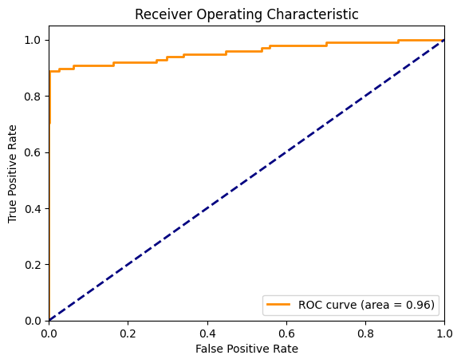

```
AUC: 0.9560526799352267
```

```python
from sklearn.metrics import roc_curve, auc
import matplotlib.pyplot as plt

# Calculate the probabilities of each class
y_prob = log_reg.predict_proba(X_test)[:, 1]

# Calculate ROC curve
fpr, tpr, thresholds = roc_curve(y_test, y_prob)

# Calculate AUC
roc_auc = auc(fpr, tpr)

# Plot ROC curve
plt.figure()
plt.plot(fpr, tpr, color='darkorange', lw=2, label=f'ROC curve (area = {roc_auc:.2f})')
plt.plot([0, 1], [0, 1], color='navy', lw=2, linestyle='--')
plt.xlim([0.0, 1.0])
plt.ylim([0.0, 1.05])
plt.xlabel('False Positive Rate')
plt.ylabel('True Positive Rate')
plt.title('Receiver Operating Characteristic')
plt.legend(loc="lower right")
plt.show()

print(f"AUC: {roc_auc}")
```

An AUC (Area Under the ROC Curve) of 0.956 suggests that the logistic regression model performs exceptionally well in distinguishing between fraudulent and non-fraudulent transactions.  
Model Performance: The ROC curve, which plots the true positive rate against the false positive rate at various threshold settings, likely shows a steep curve towards the top-left corner of the plot. This shape indicates that the model achieves a high true positive rate (recall) while maintaining a low false positive rate, which is ideal for fraud detection systems where both catching as many frauds as possible and maintaining user trust by minimizing false alarms are crucial.

**Train KNN Classifier**

```python
from sklearn.neighbors import KNeighborsClassifier

# Initialize the KNN model
knn = KNeighborsClassifier(n_neighbors=5)

# Train the model on the training data
knn.fit(X_train, y_train)

# Make predictions on the test set
y_pred_knn = knn.predict(X_test)

# Evaluate the model
accuracy_knn = accuracy_score(y_test, y_pred_knn)
precision_knn = precision_score(y_test, y_pred_knn)
recall_knn = recall_score(y_test, y_pred_knn)
f1_knn = f1_score(y_test, y_pred_knn)

print(f"KNN Accuracy: {accuracy_knn}")
print(f"KNN Precision: {precision_knn}")
print(f"KNN Recall: {recall_knn}")
print(f"KNN F1-Score: {f1_knn}")
```

```
KNN Accuracy: 0.9995435553526912
KNN Precision: 0.9186046511627907
KNN Recall: 0.8061224489795918
KNN F1-Score: 0.858695652173913
```

The table provides a clear comparison between the two models across four key performance metrics. The KNN model outperforms the logistic regression model in all metrics, indicating a higher overall effectiveness in identifying fraudulent transactions with a better balance between precision and recall, as reflected in the higher F1-score.

The SVC Model

```python
from sklearn.svm import SVC

# Initialize the SVM model
svm = SVC(kernel='linear', probability=True, random_state=42)

# Train the model on the training data
svm.fit(X_train, y_train)

# Make predictions on the test set
y_pred_svm = svm.predict(X_test)

# Evaluate the model
accuracy_svm = accuracy_score(y_test, y_pred_svm)
precision_svm = precision_score(y_test, y_pred_svm)
recall_svm = recall_score(y_test, y_pred_svm)
f1_svm = f1_score(y_test, y_pred_svm)

print(f"SVM Accuracy: {accuracy_svm}")
print(f"SVM Precision: {precision_svm}")
print(f"SVM Recall: {recall_svm}")
print(f"SVM F1-Score: {f1_svm}")
```

[output not shown]

*THe SVM clasification, were not able to run. i tried it many time and every time tooks more than 10 mins and nothing at the end